# NYCFlights: Arrival Delay Logictic Model

Abhishek Chaturvedi

04/30/2017

## Logsitic and Inverse Logistic Transformation

- Write an R function for the logistic function. The function should accept a `numeric` vector with values `[-Inf,Inf]` and produce a numeric vector in the the range `[0,1]`.
- Plot the logistic function from `[-10,10]`
- Write a R function for the inverse logistic function. The function should accept a `numeric` vector with values `[0,1]` and prodcuce a numeric vector in the range `[-Inf,Inf]`
- Plot the Inverse Logistic function from `[0,1]`

**Hint:** For plotting curves see `?graphics::curve` or `?ggplot2::stat_function`

```r
library("ggplot2")

myLogistic <- function(x) {
  return(1/(1+exp(-x)))
}

x1 <- c(-10:10)
myLogistic(x1)
```

```
##  [1] 4.539787e-05 1.233946e-04 3.353501e-04 9.110512e-04 2.472623e-03
##  [6] 6.692851e-03 1.798621e-02 4.742587e-02 1.192029e-01 2.689414e-01
## [11] 5.000000e-01 7.310586e-01 8.807971e-01 9.525741e-01 9.820138e-01
## [16] 9.933071e-01 9.975274e-01 9.990889e-01 9.996646e-01 9.998766e-01
## [21] 9.999546e-01
```

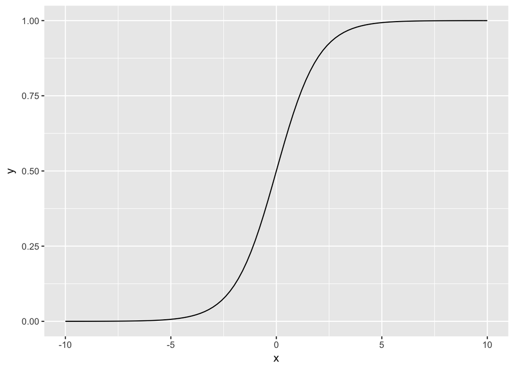

```r
ggplot(data.frame(x = x1) , aes(x)) +
  stat_function(fun = myLogistic, geom = "line")
```

```r
myInverseLogistic <- function(x){
  return(log(x/(1-x)))
}

x2 <- c(0,0.05,0.1,0.2,0.3,0.6,0.8,0.9,0.95,1)
myInverseLogistic(x2)
```

```
##  [1]       -Inf -2.9444390 -2.1972246 -1.3862944 -0.8472979  0.4054651
##  [7]  1.3862944  2.1972246  2.9444390        Inf
```

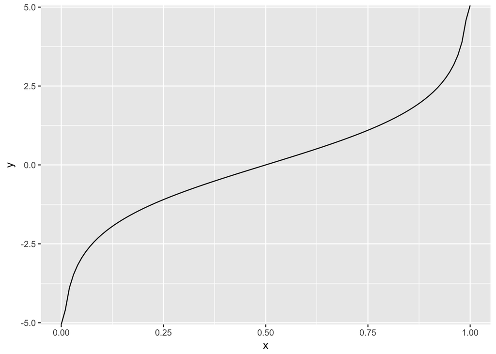

```r
ggplot(data.frame(x = x2) , aes(x)) +
  stat_function(fun = myInverseLogistic, geom = "line")
```

# NYCFlights Model

Using the rectangular data that you created from the earlier assignment and following theexample from the text and class, create a model for arr_delay >= 22 minutes. Describe/Explain each of the steps and show all work.

KNIT YOUR DOCUMENT AS *HTML* AND SUBMIT IT AND THE `Rmd` file to your repository.

```r
library('data.table')

flightsData <- fread("data/flights.csv")
planesData <- fread("data/planes.csv")
airportsData <- fread("data/airports.csv")
weatherData <- fread("data/weather.csv")

flightsPlanesData <- merge(flightsData,planesData, by.x="tailnum", by.y="tailnum" , all.x = TRUE, suffixes = c(".flights", ".planes"))

flightsPlanesOriginData <- merge(flightsPlanesData,airportsData, by.x = "origin", by.y = "faa", all.x = TRUE, suffixes = c(".flights", ".origin"))

flightsPlanesOriginDestinationData <- merge(flightsPlanesOriginData,airportsData, by.x = "dest", by.y = "faa", all.x = TRUE, suffixes = c(".origin", ".dest"))

flightsPlanesOriginDestinationWeatherData <- merge(flightsPlanesOriginDestinationData,weatherData, by.x = c("year.flights", "month", "day", "origin", "time_hour"), by.y = c("year", "month", "day", "origin", "time_hour"), all.x = TRUE, suffixes = c(".flights", ".weather"), allow.cartesian=FALSE)

flights_data_joined <- flightsPlanesOriginDestinationWeatherData[sample(.N,50000)]

# my old model consists of arr_delay,humid,dep_time,sched_dep_time,sched_arr_time,dep_delay,origin

y <- "arr_delay"
xs <- c('humid','dep_time', 'sched_dep_time','sched_arr_time','dep_delay','origin')

yx <- flights_data_joined[,c(y,xs), with=FALSE]
model1 <- lm(arr_delay ~ ., data=yx)
summary(model1)
```

```
##
## Call:
## lm(formula = arr_delay ~ ., data = yx)
##
## Residuals:
##     Min      1Q  Median      3Q     Max
## -74.874 -10.262  -1.626   8.325 132.778
##
## Coefficients:
##                 Estimate Std. Error t value Pr(>|t|)
## (Intercept)    -8.102127   0.527569 -15.357  < 2e-16 ***
## humid           0.101455   0.004980  20.372  < 2e-16 ***
## dep_time        0.024224   0.005866   4.130 3.64e-05 ***
## sched_dep_time -0.001306   0.005879  -0.222  0.82416
## sched_arr_time -0.021710   0.001169 -18.569  < 2e-16 ***
## dep_delay       0.983553   0.010402  94.553  < 2e-16 ***
## originJFK       0.760913   0.233029   3.265  0.00109 **
## originLGA       2.077407   0.226402   9.176  < 2e-16 ***
## ---
## Signif. codes:  0 '***' 0.001 '**' 0.01 '*' 0.05 '.' 0.1 ' ' 1
##
## Residual standard error: 16.6 on 31402 degrees of freedom
##   (18590 observations deleted due to missingness)
## Multiple R-squared:  0.8056, Adjusted R-squared:  0.8056
## F-statistic: 1.859e+04 on 7 and 31402 DF,  p-value: < 2.2e-16
```

```r
# modifying data to create a new column 'gt22' for flights more than 22 hours delay
yx <- within(yx, gt22 <- arr_delay>=22)

model2 <- glm(formula = gt22 ~ . - arr_delay, family=binomial, data=yx)
summary(model2)
```

```
##
## Call:
## glm(formula = gt22 ~ . - arr_delay, family = binomial, data = yx)
##
## Deviance Residuals:
##     Min       1Q   Median       3Q      Max
## -2.7568  -0.3173  -0.2431  -0.1879   3.0521
##
## Coefficients:
##                  Estimate Std. Error z value Pr(>|z|)
## (Intercept)    -4.3461882  0.1393565 -31.188  < 2e-16 ***
## humid           0.0185073  0.0012385  14.943  < 2e-16 ***
## dep_time        0.0046304  0.0014691   3.152  0.00162 **
## sched_dep_time -0.0042821  0.0014724  -2.908  0.00363 **
## sched_arr_time -0.0001351  0.0002996  -0.451  0.65195
## dep_delay       0.0993109  0.0030116  32.976  < 2e-16 ***
## originJFK       0.0844230  0.0602092   1.402  0.16087
## originLGA       0.3564540  0.0587379   6.069 1.29e-09 ***
## ---
## Signif. codes:  0 '***' 0.001 '**' 0.01 '*' 0.05 '.' 0.1 ' ' 1
##
## (Dispersion parameter for binomial family taken to be 1)
##
##     Null deviance: 26235  on 31409  degrees of freedom
## Residual deviance: 12702  on 31402  degrees of freedom
##   (18590 observations deleted due to missingness)
## AIC: 12718
##
## Number of Fisher Scoring iterations: 7
```

```r
# naive model to compare with above model

naiveModel <- glm(formula = gt22 ~ 1, family=binomial, data=yx)

summary(naiveModel)
```

```
##
## Call:
## glm(formula = gt22 ~ 1, family = binomial, data = yx)
##
## Deviance Residuals:
##    Min      1Q  Median      3Q     Max
## -0.663  -0.663  -0.663  -0.663   1.802
##
## Coefficients:
##             Estimate Std. Error z value Pr(>|z|)
## (Intercept) -1.40311    0.01139  -123.1   <2e-16 ***
## ---
## Signif. codes:  0 '***' 0.001 '**' 0.01 '*' 0.05 '.' 0.1 ' ' 1
##
## (Dispersion parameter for binomial family taken to be 1)
##
##     Null deviance: 48302  on 48625  degrees of freedom
## Residual deviance: 48302  on 48625  degrees of freedom
##   (1374 observations deleted due to missingness)
## AIC: 48304
##
## Number of Fisher Scoring iterations: 4
```

# Question:

Is this a good model?

AIC has improved compare to the naive model which suggests its a good model

# PART B:

Your model should be good at explaining tardiness. Now, assume that your job is to predict arrival delays a month in advance. You can no longer use all the features in your model. Retrain your model using only features that will be *known* only a month in advance of the departure time. Show all steps as above.

## Answer:

### my old model consists of

arr_delay,humid,dep_time,sched_dep_time,sched_arr_time,dep_delay,origin

out of this humid, dep_delay will not be available so the new model will be

```r
y <- "arr_delay"
xs <- c('dep_time', 'sched_dep_time','sched_arr_time','origin')

yx <- flights_data_joined[,c(y,xs), with=FALSE]

model3 <- lm(arr_delay ~ . , data=yx)

summary(model3)
```

```
##
## Call:
## lm(formula = arr_delay ~ ., data = yx)
##
## Residuals:
##    Min     1Q Median     3Q    Max
## -94.65 -21.90  -8.78   8.33 917.74
##
## Coefficients:
##                  Estimate Std. Error t value Pr(>|t|)
## (Intercept)    -1.164e+01  6.799e-01 -17.121  < 2e-16 ***
## dep_time        6.730e-02  1.345e-03  50.032  < 2e-16 ***
## sched_dep_time -4.323e-02  1.390e-03 -31.106  < 2e-16 ***
## sched_arr_time -8.360e-03  6.374e-04 -13.116  < 2e-16 ***
## originJFK      -3.120e+00  4.610e-01  -6.768 1.33e-11 ***
## originLGA      -1.699e+00  4.687e-01  -3.625  0.00029 ***
## ---
## Signif. codes:  0 '***' 0.001 '**' 0.01 '*' 0.05 '.' 0.1 ' ' 1
##
## Residual standard error: 42.09 on 48620 degrees of freedom
##   (1374 observations deleted due to missingness)
## Multiple R-squared:  0.08034,    Adjusted R-squared:  0.08025
## F-statistic: 849.5 on 5 and 48620 DF,  p-value: < 2.2e-16
```

```r
# lets add carrier

y <- "arr_delay"
xs <- c('dep_time', 'sched_dep_time','sched_arr_time','origin','carrier')

yx <- flights_data_joined[,c(y,xs), with=FALSE]
model4 <- lm(arr_delay ~ . , data=yx)

summary(model4)
```

```
##
## Call:
## lm(formula = arr_delay ~ ., data = yx)
##
## Residuals:
##    Min     1Q Median     3Q    Max
## -87.85 -21.96  -8.65   8.50 914.02
##
## Coefficients:
##                  Estimate Std. Error t value Pr(>|t|)
## (Intercept)    -1.204e+01  1.177e+00 -10.230  < 2e-16 ***
## dep_time        6.639e-02  1.342e-03  49.489  < 2e-16 ***
## sched_dep_time -4.441e-02  1.389e-03 -31.965  < 2e-16 ***
## sched_arr_time -6.417e-03  6.448e-04  -9.953  < 2e-16 ***
## originJFK      -3.119e+00  6.297e-01  -4.953 7.34e-07 ***
## originLGA      -1.190e+00  5.800e-01  -2.051 0.040232 *
## carrierAA      -5.086e+00  1.045e+00  -4.867 1.14e-06 ***
## carrierAS      -8.655e+00  4.245e+00  -2.039 0.041448 *
## carrierB6       4.368e+00  9.519e-01   4.589 4.47e-06 ***
## carrierDL      -3.794e+00  9.840e-01  -3.856 0.000115 ***
## carrierEV       5.346e+00  1.064e+00   5.024 5.09e-07 ***
## carrierF9       1.498e+01  4.068e+00   3.682 0.000231 ***
## carrierFL       1.039e+01  2.174e+00   4.780 1.76e-06 ***
## carrierHA      -6.977e+00  5.819e+00  -1.199 0.230543
## carrierMQ       3.272e+00  1.105e+00   2.961 0.003067 **
## carrierOO      -1.097e+01  2.963e+01  -0.370 0.711298
## carrierUA      -4.258e+00  1.043e+00  -4.082 4.48e-05 ***
## carrierUS      -1.680e+00  1.184e+00  -1.419 0.155972
## carrierVX      -2.248e+00  1.750e+00  -1.285 0.198832
## carrierWN       1.908e+00  1.335e+00   1.429 0.152994
## carrierYV      -7.025e-01  4.539e+00  -0.155 0.877000
## ---
## Signif. codes:  0 '***' 0.001 '**' 0.01 '*' 0.05 '.' 0.1 ' ' 1
##
## Residual standard error: 41.89 on 48605 degrees of freedom
##   (1374 observations deleted due to missingness)
## Multiple R-squared:  0.08964,    Adjusted R-squared:  0.08926
## F-statistic: 239.3 on 20 and 48605 DF,  p-value: < 2.2e-16
```